# IODS course project

Joana

## **Experiences and learning progress during the first week:**

This week’s coursework was marked, for me, by developing a kind of feeling for *RStudio* and *R*.

1. I began, naturally, by downloading and setting up the respective programs, as well as looking around within them to see what can potentially be done with/by them. I am still quite overwhelmed by the possibilities – and from my point of view also impossibilities – with regard to the programs.
2. Next I worked on the first datacamp-exercise. It gave a short and brief introduction to R, which I definitely consider to be helpful. Yet, I also found it to a certain degree confusing, though I cannot quite explain why. As I am a *newby* myself, and never considered myself as being more interested in computers than necessary, I expect that some of my problems might derive from these aspects.
3. I have started to compile a handwritten list for myself, containing some of the *commands* given in the datacamp exercise, as well, as further commands that I stumbled upon via **this** exercise. This step may be considered *oldfashioned* by you, but to me it seems necesserary, as I have never learned *vocabularies*, if I did not at some point write them by hand. The usefulness of such a list remains to be seen, but in the least I will be able to look back on it.
4. In my third point, I mentioned *stumbled upon*. And a lot of my learning this week within the programs RStudio and GitHub truely derives from *trying to see what happens*, as my repository surely attests to. I apologize, if that causes inconveniences, when reading through them. I will try to do better in the future. This does not mean that the instructions given during the course-sessions, and the other help-options were not useful to me, after all, it seems that what needed to ended up on the page.
5. Finally, I noticed that with regard to the programming language, I really need to pay a lot more attention to details. In the datacamp-exercise, as well as, in this exercise I tend to overlook details such as the quotationmarks…

All in all, I still am very insecure with the programming language and I still have a long way to go, I think.

## My Hopes for the course:

I have never used R or GitHub before and thus am very unsure about it. I hope that aside from learning the “How to…”, I will also learn about the values of open access to data and research in general, as well as, the downsides. In other words: I am hoping for a lively discussion.

Furthermore, I hope that with the aid of this course I can get over at least some of my *fear* with regard to programming language and programs in general.

[Way to go to my repository](https://github.com/JoaWe/IODS-project)

# **Week 2: Let’s start with the data**

*Describe the work you have done this week and summarize your learning.*

## Data at a glance

After reading the data into R, I took a glimpse at the provided data. Here are my first observations:

1. The data-set consists of 183 observations relating to 60 variables.
2. Except for the variables “Age”, “Attitude”, “Points”, and “gender” the data appear to be provided by a scale from 1 to 5. (In the print out, however, 167 rows were omitted, thus a higher scale may be possible)
3. The variable “gender”, as a qualitative characteristic, are given as binary text-data in “M” (=male) and “F” (=female).
4. The variable “Age”, is provided as number of years, and derived from the provided year of birth by the respondent.

## Data-Wrangling Attempts

**1. I printed and summarized the variable “gender”:**

- the result showed that 122 respondents were female, and 61 were male.

**2. I printed and summarized the variable “Age”.**

- The age-range is between 17 and 55 years.
- The average age is 25,58 years.
- The median-age is 22 years.

**3. I printed and summarized the variable “Points”**

- At this point the variable ranges between 0 and 33.
- The average points are 20,61.
- The median-value is 22,00 points.

**4. I scaled down the variable “Attitude” by 10, afterwards I printed and summarized it**

- The variable - according to the additional information homepage - intends to reflect the respondent’s “global attitude towards statistics”
- The range of the variable-values is now between 1,4 and 5,00.
- The average-value is 3,121.
- The Median-value is 3,2.

**5. I attempted to establish the combination variables “deep_questions”, “surface_questions”, and “strategic_questions”**

- I combined the variables for each as it was done in the datacamp-exercises (“deep_questions” and “surface_questions” thus resulted out of a combination of 12 variables each, while “strategic_questions” became a combination of 8 variables).
- Next I created the columns out of the individual new variables and named them “deep_columns”, “surface_columns”, and “startegic_columns”.
- I attemped to apply the rowMeans function on each. While in the print outs it showed me the columns results, I could not get the summarise function to work. I am not sure if that is supposed to be that way.

**6. I created the new data-set “learning2014”**

- At this point it consisted of 183 observations and 7 variables.
- The variable names are “gender”, “Age”, “Attitude”, “deep”, “stra”, “surf”, and “Points”.
- After I tried to exclude respondents with 0 points within the “Points”-variable my dataset consisted of only 166 observations for the 7 given variables.

Up to this point, it appears to me as though it worked according to the instructions…

## Trying to work with the newly established data-set “learning2014”

It appears, that I have managed to create the csv.file, but I am not sure if I manage any further… Here, I guess, you will be able to see why I am not happy with it…

```r
learning2014 <- read.csv("C:\\Users\\Ani\\Documents\\GitHub\\IODS-project\\data\\learning2014.csv", header=TRUE)
```

Looking at the structure of my dataset:

```r
dim(learning2014)
```

```
## [1] 166   7
```

Trying to explore the structure of my data:

```r
str(learning2014)
```

```
## 'data.frame':    166 obs. of  7 variables:
##  $ gender  : Factor w/ 2 levels "F","M": 1 2 1 2 2 1 2 1 2 1 ...
##  $ Age     : int  53 55 49 53 49 38 50 37 37 42 ...
##  $ attitude: num  3.7 3.1 2.5 3.5 3.7 3.8 3.5 2.9 3.8 2.1 ...
##  $ deep    : num  3.58 2.92 3.5 3.5 3.67 ...
##  $ stra    : num  3.38 2.75 3.62 3.12 3.62 ...
##  $ surf    : num  2.58 3.17 2.25 2.25 2.83 ...
##  $ points  : num  2.5 1.2 2.4 1 2.2 2.1 2.1 3.1 2.4 2.6 ...
```

```r
head(learning2014)
```

```
##   gender Age attitude     deep  stra     surf points
## 1      F  53      3.7 3.583333 3.375 2.583333    2.5
## 2      M  55      3.1 2.916667 2.750 3.166667    1.2
## 3      F  49      2.5 3.500000 3.625 2.250000    2.4
## 4      M  53      3.5 3.500000 3.125 2.250000    1.0
## 5      M  49      3.7 3.666667 3.625 2.833333    2.2
## 6      F  38      3.8 4.750000 3.625 2.416667    2.1
```

It appears that the 7 variables “gender”, “Age”, “attitude”, “deep”, “surf”, stra“, and”points" are there. I furthermore appear to be having the 166 observations. Let’s see how it may, or may not work out with the rest of the tasks…

**“Gender”** represents the respondents sex, in terms of “F” (female) and “M” (male).

**“Age”** represents the age in number of years and is calculated from the year of birth provided by the respective respondent.

**“attitude”** reflects the respondent’s general attitude towards statistics. The original dataset values have been scaled down by 10.

**“deep”, “surf”, and “stra”** are combination variables, the respondents answers are represented within a scale from 1 to 5:

- **“deep”** is set up as the means of a series of 12 questions relating to the respondent’s learning methods and their impacts.
- **“surf”** is equally set up as the means of 12 questions, which in this case relate to the respondent’s learning habits.
- **“stra”** is a combination-variable set up out of the mean of the answers given to 8 questions relating to the respondent’s organization habits with regard to their studies.

**“points”** is a variable relating to the respondent’s exam-points. The original scale of this variable ranged from 0 to 33. I scaled the range down by a factor of 10. Respondents with 0 exam-points have been excluded from the data-set.

## Graphical overview of the data

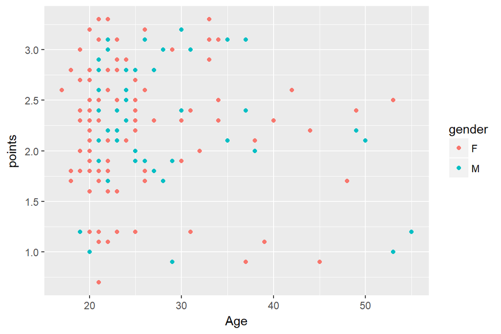

```r
library(ggplot2)

p1 <- ggplot(learning2014, aes(x = Age, y = points))
p1 <- ggplot(learning2014, aes (x = Age, y = points, col = gender))
p2 <- p1 + geom_point()
p2
```

```r
summary(learning2014$Age)
```

```
##    Min. 1st Qu.  Median    Mean 3rd Qu.    Max.
##   17.00   21.00   22.00   25.51   27.00   55.00
```

```r
summary(learning2014$points)
```

```
##    Min. 1st Qu.  Median    Mean 3rd Qu.    Max.
##   0.700   1.900   2.300   2.272   2.775   3.300
```

The summary of the variable *“Age”* shows that the minimum-age of the respondents is 17, the maximimum-age 55. The plot, thereby indicates that the majority of the respondents is to be found within the age-group of up to 30 years. The summary of the variable *points* displays that the respondent with the least points has 0.7, while the respondent with the highest points has 3.3. Furthermore, the plot indicates that the respondents with the higher points are up to 40 years old.

2. Relating Age with deep distinguished by gender

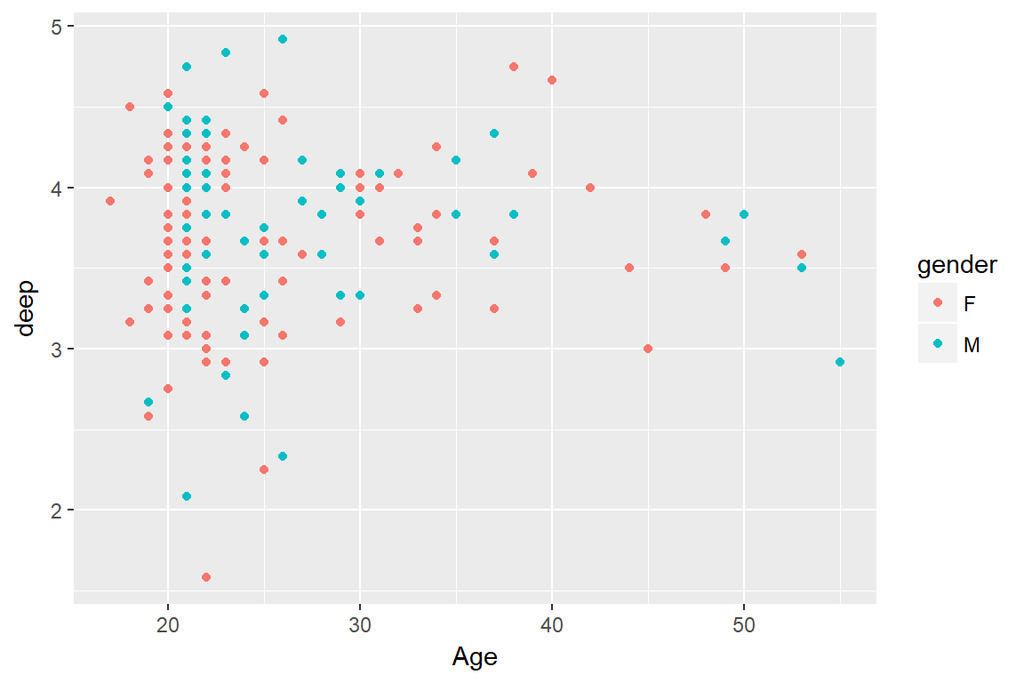

```r
library(ggplot2)

p1 <- ggplot(learning2014, aes(x = Age, y = deep))
p1 <- ggplot(learning2014, aes (x = Age, y = deep, col = gender))
p2 <- p1 + geom_point()
p2
```

```r
summary(learning2014$deep)
```

```
##    Min. 1st Qu.  Median    Mean 3rd Qu.    Max.
##   1.583   3.333   3.667   3.680   4.083   4.917
```

3. Relating Age with surf distinguished by gender

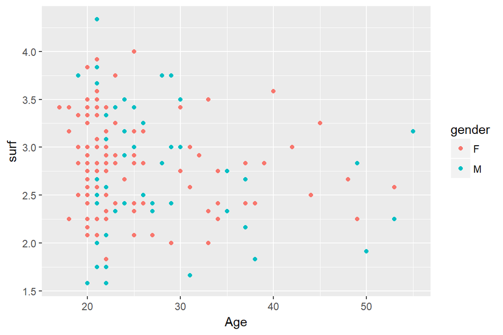

```r
library(ggplot2)

p1 <- ggplot(learning2014, aes(x = Age, y = surf))
p1 <- ggplot(learning2014, aes (x = Age, y = surf, col = gender))
p2 <- p1 + geom_point()
p2
```

```r
summary(learning2014$surf)
```

```
##    Min. 1st Qu.  Median    Mean 3rd Qu.    Max.
##   1.583   2.417   2.833   2.787   3.167   4.333
```

4. Relating Age with stra distinguished by gender

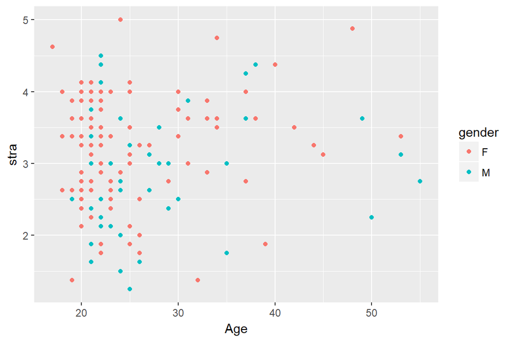

```r
library(ggplot2)

p1 <- ggplot(learning2014, aes(x = Age, y = stra))
p1 <- ggplot(learning2014, aes (x = Age, y = stra, col = gender))
p2 <- p1 + geom_point()
p2
```

```r
summary(learning2014$stra)
```

```
##    Min. 1st Qu.  Median    Mean 3rd Qu.    Max.
##   1.250   2.625   3.188   3.121   3.625   5.000
```

## Attempting multiple regression

With the next code I have attempted to undertake multiple regression with points as the target-variable, based on the variables “attitude”, “stra”, and “surf”, incl. the diagnostic plots:

```r
library(ggplot2)

my_model2 <- lm(points ~ attitude + stra + surf, data = learning2014)
summary(my_model2)
```

```
##
## Call:
## lm(formula = points ~ attitude + stra + surf, data = learning2014)
##
## Residuals:
##      Min       1Q   Median       3Q      Max
## -1.71550 -0.34346  0.05156  0.36401  1.08952
##
## Coefficients:
##             Estimate Std. Error t value Pr(>|t|)
## (Intercept)  1.10171    0.36837   2.991  0.00322 **
## attitude     0.33952    0.05741   5.913 1.93e-08 ***
## stra         0.08531    0.05416   1.575  0.11716
## surf        -0.05861    0.08014  -0.731  0.46563
## ---
## Signif. codes:  0 '***' 0.001 '**' 0.01 '*' 0.05 '.' 0.1 ' ' 1
##
## Residual standard error: 0.5296 on 162 degrees of freedom
## Multiple R-squared:  0.2074, Adjusted R-squared:  0.1927
## F-statistic: 14.13 on 3 and 162 DF,  p-value: 3.156e-08
```

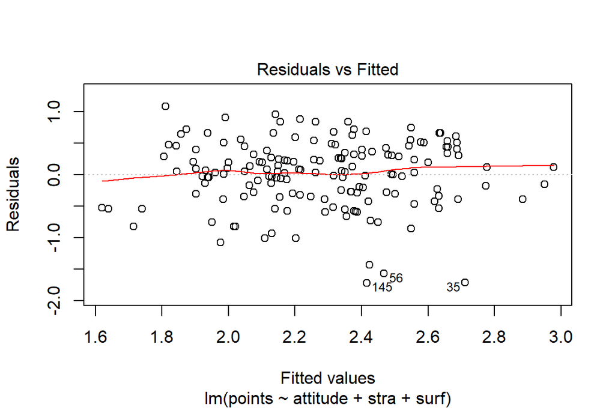

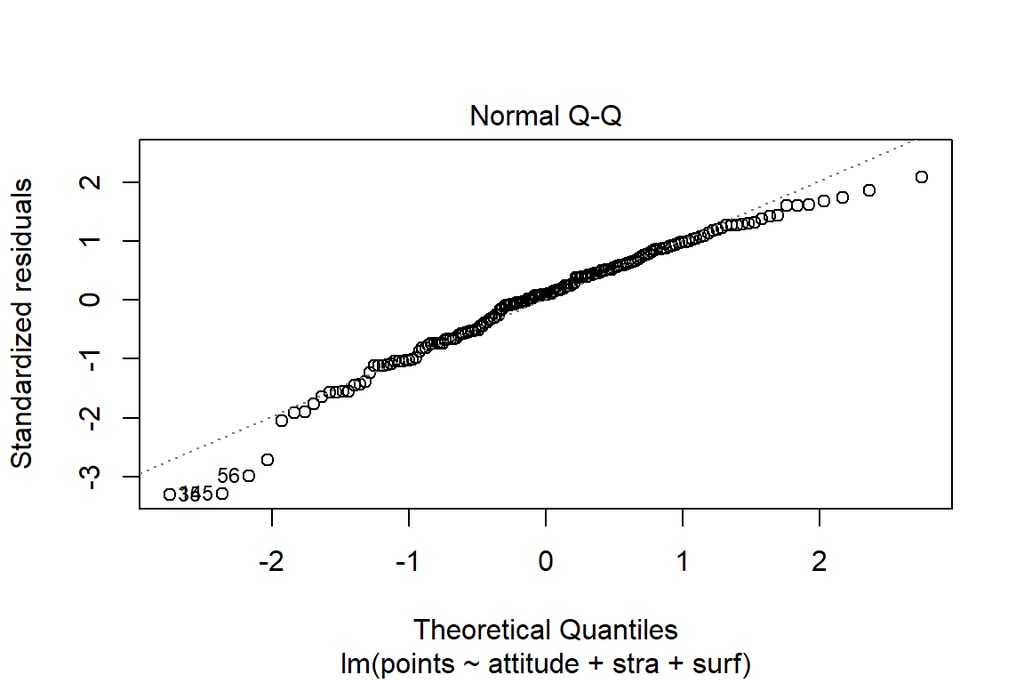

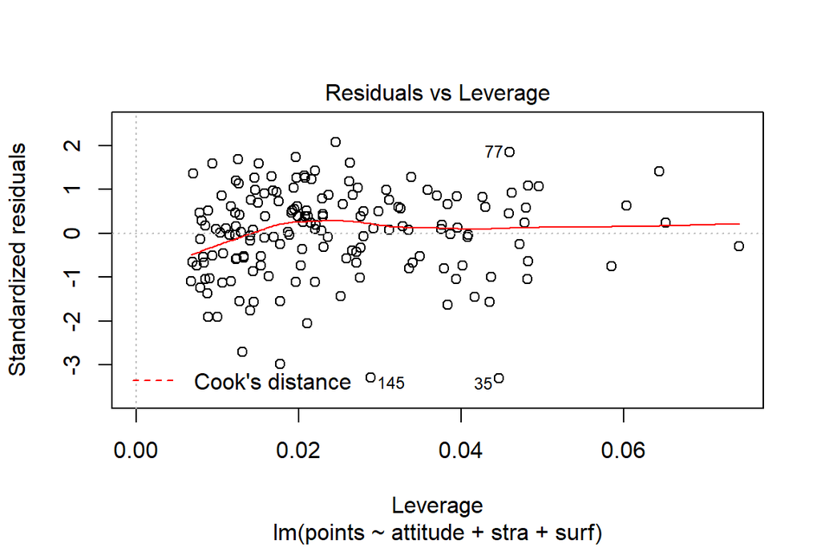

```r
plot(my_model2, which = c(1, 2, 5))
```

```r
?plot.lm
```

```
## starting httpd help server ... done
```

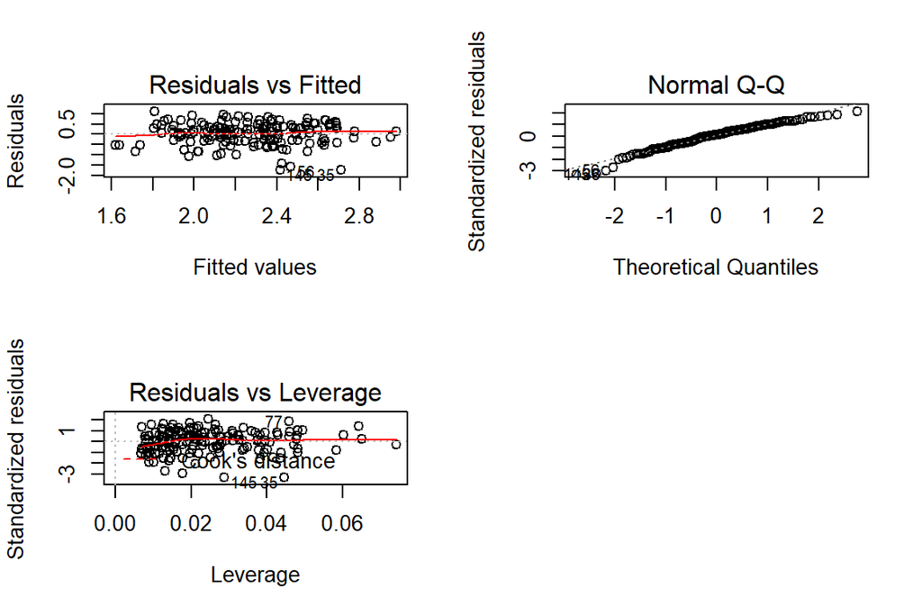

```r
par(mfrow = c(2,2))
plot(my_model2, which = c(1, 2, 5))
```

# **Week 3: Logistic Regression**

## Data at a glance

#### The original Datasets:

The data-set used here is based on the datasets provided by the [UCI Machine Learning Repository](https://archive.ics.uci.edu/ml/datasets/Student+Performance).

Citation of the dataset-reference: *P. Cortez and A. Silva. Using Data Mining to Predict Secondary School Student Performance. In A. Brito and J. Teixeira Eds., Proceedings of 5th FUture BUsiness TEChnology Conference (FUBUTEC 2008) pp. 5-12, Porto, Portugal, April, 2008, EUROSIS, ISBN 978-9077381-39-7.*

The original datasets “student_mat.csv” (including 395 observations and 33 variables, with regard to the subject of mathematics) and “student_por.csv” (consisting of 649 observations and 33 variables, relating to the subject of Portuguese) were established from data collected at two Portuguese secondary schools.

The data attributes of these original datasets include student grades, demographic, social and school related features) and it was collected by using school reports and questionnaires.

The age range of the respondents lies between 15 and 22 years.

The three final variables “G1”, “G2”, and “G3” relate to the specific grades the respondent has achieved either in mathematics or in Portuguese, while the other variables operationalize more general conditions of the respective respondent, relating to his or her familial background, school- and leisure-time habits, and general information (i.e., for instance, age and gender).

#### The altered dataset used in this project:

In order to look at my data-wrangling coding for this week’s exercise, feel free to [go this way](https://github.com/JoaWe/IODS-project/blob/master/data/create_alc.R).

The two datasets were joined by means of using the variables “school”, “sex”, “age”, “address”, “famsize”, “Pstatus”, “Medu”, “Fedu”, “Mjob”, “Fjob”, “reason”, “nursery”,“internet” as identifiers. Only the respondents present in both datasets were kept for the newly established dataset.

Two new variables, “alc_use” and “high_use”, have been established in the new dataset, by the following means:

1.**alc_use**: The average of the answers related to weekday and weekend alcohol consumption have been taken.

2.**high_use**: Then the newly created variable “alc_use” has been utilized to create a second new variable “high_use”, which is TRUE for students for whom “alc_use”" is greater than 2.

Accordingly, this new dataset now contains **382 observations relating to 35 variables**.

- Reading the joined student alcohol-consumption data into R from my data-folder:

```r
alc <- read.csv("C:\\Users\\Ani\\Documents\\GitHub\\IODS-project\\data\\alc.csv", header=TRUE)
```

- structure of my data-set:

```r
str(alc)
```

```
## 'data.frame':    382 obs. of  35 variables:
##  $ school    : Factor w/ 2 levels "GP","MS": 1 1 1 1 1 1 1 1 1 1 ...
##  $ sex       : Factor w/ 2 levels "F","M": 1 1 1 1 1 2 2 1 2 2 ...
##  $ age       : int  18 17 15 15 16 16 16 17 15 15 ...
##  $ address   : Factor w/ 2 levels "R","U": 2 2 2 2 2 2 2 2 2 2 ...
##  $ famsize   : Factor w/ 2 levels "GT3","LE3": 1 1 2 1 1 2 2 1 2 1 ...
##  $ Pstatus   : Factor w/ 2 levels "A","T": 1 2 2 2 2 2 2 1 1 2 ...
##  $ Medu      : int  4 1 1 4 3 4 2 4 3 3 ...
##  $ Fedu      : int  4 1 1 2 3 3 2 4 2 4 ...
##  $ Mjob      : Factor w/ 5 levels "at_home","health",..: 1 1 1 2 3 4 3 3 4 3 ...
##  $ Fjob      : Factor w/ 5 levels "at_home","health",..: 5 3 3 4 3 3 3 5 3 3 ...
##  $ reason    : Factor w/ 4 levels "course","home",..: 1 1 3 2 2 4 2 2 2 2 ...
##  $ nursery   : Factor w/ 2 levels "no","yes": 2 1 2 2 2 2 2 2 2 2 ...
##  $ internet  : Factor w/ 2 levels "no","yes": 1 2 2 2 1 2 2 1 2 2 ...
##  $ guardian  : Factor w/ 3 levels "father","mother",..: 2 1 2 2 1 2 2 2 2 2 ...
```

[output cut: 21 more lines]

- the dimensions of the dataset:

```r
dim(alc)
```

```
## [1] 382  35
```

An interesting inside into the newly established dataset is provided by looking at the summary of the variable “sex”:

```r
summary(alc$sex)
```

```
##   F   M
## 198 184
```

It makes clear that, while the gender-representation of the respondents may not be an exact 50% of the total number of respondents, it does come sufficiantly close (~52% of the respondents are female). This information may come in useeful in the further analysis.

## Hypotheses relating to students’ alcohol-consumption

Accessing libraries:

```r
library(tidyr)
library(dplyr)
```

```r
library(ggplot2)
```

#### General explanations with regard to the alcohol-consumption variables

With regard to higher or lower alcohol-consumption among students certain hypotheses can be presumed relating to the following **four variables** taken from the newly established dataset “alc.csv”. These hypotheses are to be tested and (dis-)proven here. The dependent variables of interest are…

…**“alc_use”**, which displays the average-answers related to weekday and weekend alcohol consumption (from 1 = very low consumption to 5 = very high consumption) . For a brief glimpse at the respective variable, see the barplot here:

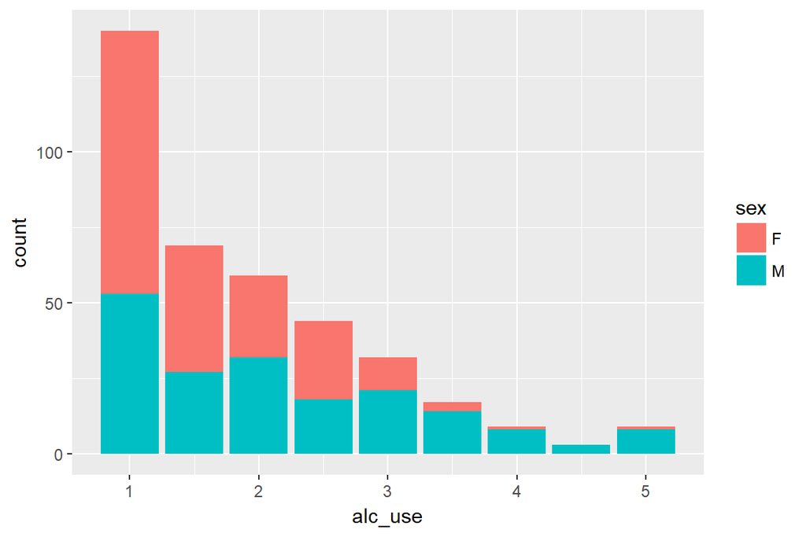

```r
g1 <- ggplot(data = alc, aes(x = alc_use, fill = sex))

g1 + geom_bar()
```

…and **“high_use”**, which is a logical column based on the variable *“alc_use”*. High usage of alcohol-consumption is therein defined as being TRUE, if the observation in the alc_use-variable is greater than 2. Take a sneak-peak at the summary of this variable:

```r
summary(alc$high_use)
```

```
##    Mode   FALSE    TRUE
## logical     268     114
```

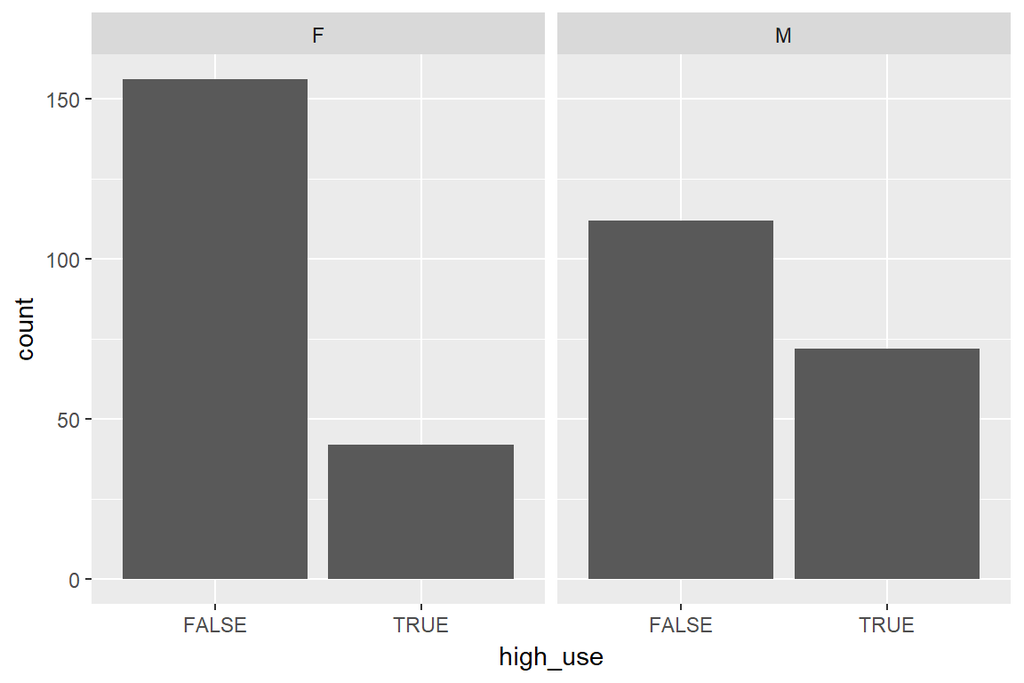

```r
g2 <- ggplot(alc, aes(high_use))

g2 + facet_wrap("sex") + geom_bar()
```

*For the interpretation of this bar-plot it needs to be remembered that the variable “high_use” is a logical column. Similar to the variable “alc_use” it was not directly answered by the respondents. The barplot shows that the majorities of both male and female respondents supposedly consume alcohol on low levels.*

##### 1. Hypothesis:

It can be assumed that a respective student’s ambitions can impact on his or her alcohol consumption habits. Accordingly, it is hypothesized that there is a negative correlation between the students’ alcohol-consumption and their interest in pursuing a higher education degree.

**dependent variable “higher”:** reports on whether - or not, the respondent aims for a higher education degree, in a binary fashion of “yes” or “no”. The summary of this variable follows here:

```r
summary(alc$higher)
```

```
##  no yes
##  18 364
```

An interesting observation at this point is that only 18 out of the 382 respondents of this dataset are *not* interested in achieving a higher educational degree.

- creating a boxplot:

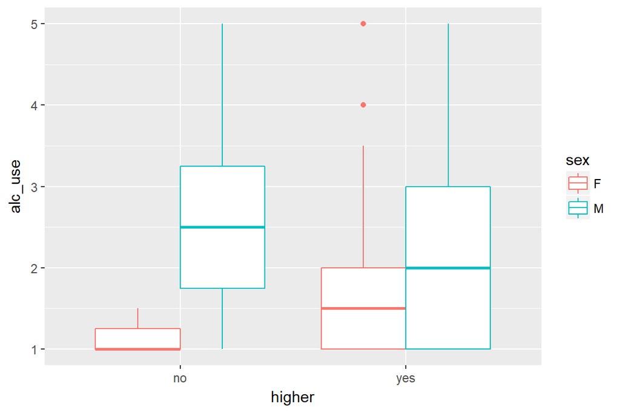

```r
library(gmodels)
g3 <- ggplot(alc, aes(x = higher, y = alc_use))
g3 <- ggplot(alc, aes(x = higher, y = alc_use, col = sex))
g3 + geom_boxplot()
```

**Observations & Interpretation:**

The boxplot is set up to visualize the potential relation between the variables of “higher” and “alc_use”, it includes the distinction of the respondents by gender.

With the exception of the box, representing the male respondents without higher education (HE) ambitions, the first quartiles start at 1 (meaning very low use of alcohol). A whisker towards the minimum is only displayed with that box (male, “no” for HE ambitions). Upwards whiskers towards the respective maximums are present on all boxes. The box for female respondents with HE-ambitions also contains two exceptions above the maximums. On both male-respondent boxes no exceptions are displayed.  
In the case of the female respondents without HE-ambitions it appears that the median lies in the same position as the 1. quartile. The responses of female students appear to be lying generally in the lower levels than those of their male equivalents. According to the boxplots, the female responses are lying below or equal to the male responses’ medians.

It appears to be very interesting to me that the female “no” (to HE) respondents in relative terms appear to be consuming the least amounts of alcohol. WHich in their case speaks against the clichee. None of the groups, however, display a consistent excessive amount of alcohol-consumption.

A point that needs to be made, however – and I apologize, if it appears to be a repition – that the variable “alc_use” represents the average of two other variables. Averages disguise, for instance extreme exceptions within the mass of observations, similarly, exceptions can raise or lower the averages. Accordingly, these results need to be viewed with care.

Furthermore, the questions relating to alcohol-consumption are answered subjectively by the respondents. And – as my hypotheses may indicate – certain stereotyping with regard to alcohol consumption are undertaken in society, which may result in a certain bias at the point, when the question is answered may be contained in the data.

##### 2. Hypothesis:

Presuming, that the time a student has to spare, impacts on his or her alcohol-consumption level, two variables are considered to be of interest:

[output not shown]

```r
summary(alc$studytime)
```

```
##    Min. 1st Qu.  Median    Mean 3rd Qu.    Max.
##   1.000   1.000   2.000   2.037   2.000   4.000
```

```r
summary(alc$activities)
```

```
##  no yes
## 181 201
```

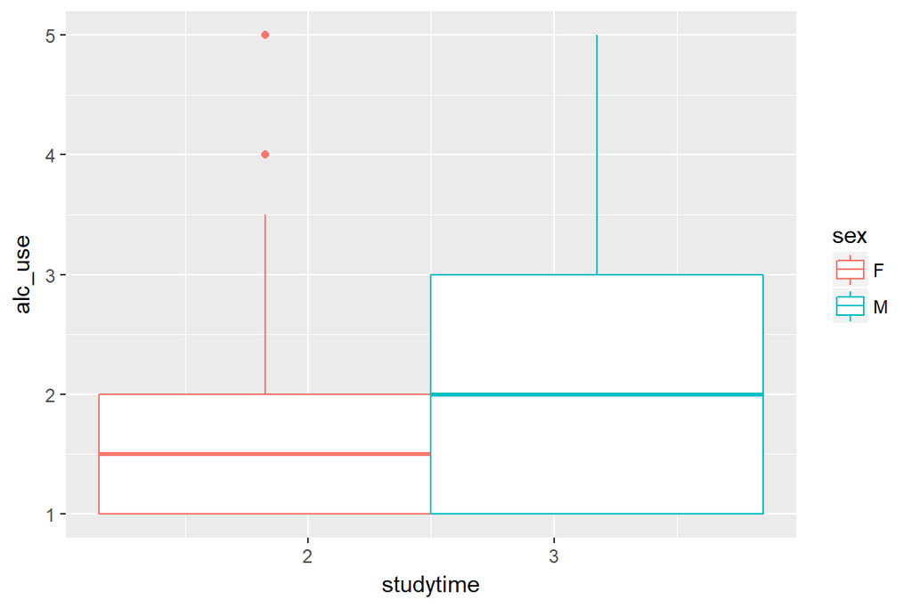

```r
library(ggplot2)

g4 <- ggplot(alc, aes(x = studytime, y = alc_use, col = sex))

g4 + geom_boxplot()
```

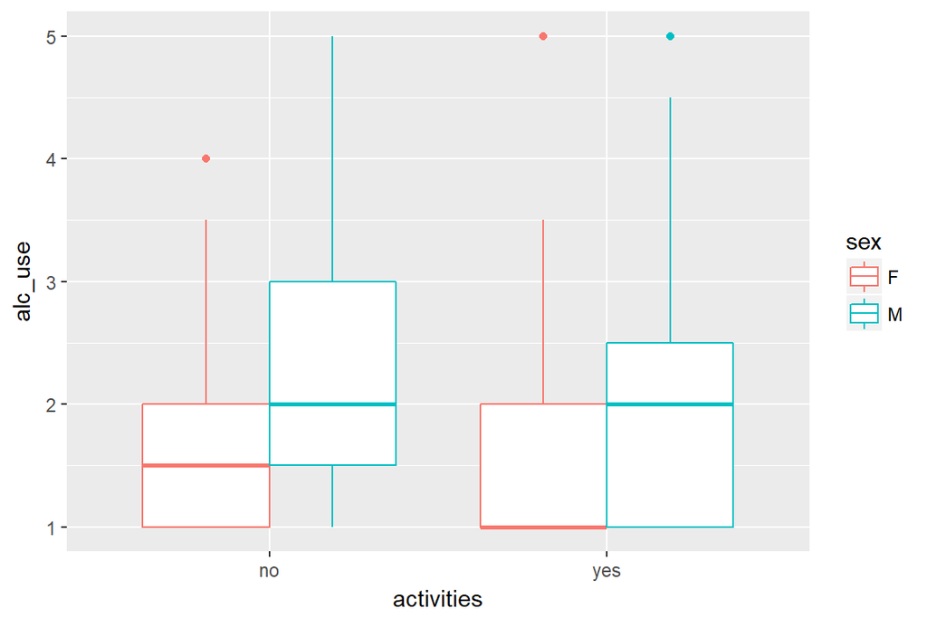

```r
g5 <- ggplot(alc, aes (x = activities, y = alc_use, col = sex))
g5 + geom_boxplot()
```

##### 3. Hypothesis:

[output not shown]

# **Clustering and Classification**

This exercise is devoted to the themes of *classification* and *clustering*.

*Classification* implies that the individual elements of a target population are categorized with the aid of specific common observations that are known to the researcher in advance. The *classification model* is trained based on the respective data. The aim is to potenially add new observations to the respective classes.

*Clusters* are combined elements of the target population, which cannot be precategorized by the researcher, neither by quantity (the number of elements belonging to each group), nor by quality (meaning the common observations). The aim of cluster-analyses is to find the commonalities by which the individual elements can then be potentially categorized.

This analysis is therefore devided into two main parts:

1. The analysis of classes by means of the *linear discriminant analysis* (LDA), and
2. the analysis of clustering by means of the *distance measures*, as well as the *k-means*, as one of the more common clustering algorithms.

**The analysis will contain the following steps:**

1. The dataset “Boston” will be briefly introduced, by means of r-functions, as well as, graphical visualization.
2. The dataset will be standardized, by means of scaling.
3. A categorical variable - named “crime” - will be established, with its aid train- and test-sets will be created.
4. A linear discriminant analysis (LDA) will be attempted, and hopefully visualized by means of an LDA (bi)plot on the train set.
5. Predictions based on the former LDA will be attempted.
6. Finally, the Boston-dataset will be reloaded and standardized, the distances will be calculated, and the k-means algorithm will be applied to the dataset.

## Data at a glance

### Loading and exploring the data *Boston*:

```r
#activating libraries
library(tidyr)
library(corrplot)
library(ggplot2)
library(dplyr)

#access MASS-Package
library(MASS)
#load the data
data("Boston")

#exploring the data
dim(Boston)
```

```
## [1] 506  14
```

```r
str(Boston)
```

```
## 'data.frame':    506 obs. of  14 variables:
##  $ crim   : num  0.00632 0.02731 0.02729 0.03237 0.06905 ...
##  $ zn     : num  18 0 0 0 0 0 12.5 12.5 12.5 12.5 ...
##  $ indus  : num  2.31 7.07 7.07 2.18 2.18 2.18 7.87 7.87 7.87 7.87 ...
##  $ chas   : int  0 0 0 0 0 0 0 0 0 0 ...
##  $ nox    : num  0.538 0.469 0.469 0.458 0.458 0.458 0.524 0.524 0.524 0.524 ...
##  $ rm     : num  6.58 6.42 7.18 7 7.15 ...
##  $ age    : num  65.2 78.9 61.1 45.8 54.2 58.7 66.6 96.1 100 85.9 ...
##  $ dis    : num  4.09 4.97 4.97 6.06 6.06 ...
##  $ rad    : int  1 2 2 3 3 3 5 5 5 5 ...
##  $ tax    : num  296 242 242 222 222 222 311 311 311 311 ...
##  $ ptratio: num  15.3 17.8 17.8 18.7 18.7 18.7 15.2 15.2 15.2 15.2 ...
##  $ black  : num  397 397 393 395 397 ...
##  $ lstat  : num  4.98 9.14 4.03 2.94 5.33 ...
##  $ medv   : num  24 21.6 34.7 33.4 36.2 28.7 22.9 27.1 16.5 18.9 ...
```

```r
summary(Boston)
```

```
##       crim                zn             indus            chas
##  Min.   : 0.00632   Min.   :  0.00   Min.   : 0.46   Min.   :0.00000
##  1st Qu.: 0.08204   1st Qu.:  0.00   1st Qu.: 5.19   1st Qu.:0.00000
##  Median : 0.25651   Median :  0.00   Median : 9.69   Median :0.00000
##  Mean   : 3.61352   Mean   : 11.36   Mean   :11.14   Mean   :0.06917
##  3rd Qu.: 3.67708   3rd Qu.: 12.50   3rd Qu.:18.10   3rd Qu.:0.00000
##  Max.   :88.97620   Max.   :100.00   Max.   :27.74   Max.   :1.00000
##       nox               rm             age              dis
##  Min.   :0.3850   Min.   :3.561   Min.   :  2.90   Min.   : 1.130
##  1st Qu.:0.4490   1st Qu.:5.886   1st Qu.: 45.02   1st Qu.: 2.100
##  Median :0.5380   Median :6.208   Median : 77.50   Median : 3.207
##  Mean   :0.5547   Mean   :6.285   Mean   : 68.57   Mean   : 3.795
##  3rd Qu.:0.6240   3rd Qu.:6.623   3rd Qu.: 94.08   3rd Qu.: 5.188
##  Max.   :0.8710   Max.   :8.780   Max.   :100.00   Max.   :12.127
##       rad              tax           ptratio          black
##  Min.   : 1.000   Min.   :187.0   Min.   :12.60   Min.   :  0.32
##  1st Qu.: 4.000   1st Qu.:279.0   1st Qu.:17.40   1st Qu.:375.38
##  Median : 5.000   Median :330.0   Median :19.05   Median :391.44
##  Mean   : 9.549   Mean   :408.2   Mean   :18.46   Mean   :356.67
##  3rd Qu.:24.000   3rd Qu.:666.0   3rd Qu.:20.20   3rd Qu.:396.23
##  Max.   :24.000   Max.   :711.0   Max.   :22.00   Max.   :396.90
##      lstat            medv
##  Min.   : 1.73   Min.   : 5.00
##  1st Qu.: 6.95   1st Qu.:17.02
##  Median :11.36   Median :21.20
##  Mean   :12.65   Mean   :22.53
##  3rd Qu.:16.95   3rd Qu.:25.00
##  Max.   :37.97   Max.   :50.00
```

The dataset consists of 14 variables including 506 observations relating to the city of Boston.

Here is a list of the variables and their respective meanings:

- **crim:** per capita crime rate by town.
- **zn:** proportion of residential land zoned for lots over 25,000 sq.ft.
- **indus:** proportion of non-retail business acres per town.
- **chas:** Charles River dummy variable (= 1 if tract bounds river; 0 otherwise).
- **nox:** nitrogen oxides concentration (parts per 10 million).
- **rm:** average number of rooms per dwelling.
- **age:** proportion of owner-occupied units built prior to 1940.
- **dis:** weighted mean of distances to five Boston employment centres.
- **rad:** index of accessibility to radial highways.
- **tax:** full-value property-tax rate per $10,000.
- **ptratio:** pupil-teacher ratio by town.
- **black:** 1000(Bk - 0.63)^2 where Bk is the proportion of blacks by town.
- **lstat:** lower status of the population (percent).
- **medv:** median value of owner-occupied homes in $1000s.

*These definitions and further information can be looked up from [here](https://stat.ethz.ch/R-manual/R-devel/library/MASS/html/Boston.html).*

The variable **crim** will be of particular importance in the next steps that are devoted to the issue of classification in this exercise.

#### Graphical Overview of the dataset:

```r
#calculating the correlation-matrix & rounding
cor_matrix <- cor(Boston) %>% round(digits = 2)

#printing the correlation-matrix
cor_matrix
```

```
##          crim    zn indus  chas   nox    rm   age   dis   rad   tax
## crim     1.00 -0.20  0.41 -0.06  0.42 -0.22  0.35 -0.38  0.63  0.58
## zn      -0.20  1.00 -0.53 -0.04 -0.52  0.31 -0.57  0.66 -0.31 -0.31
## indus    0.41 -0.53  1.00  0.06  0.76 -0.39  0.64 -0.71  0.60  0.72
## chas    -0.06 -0.04  0.06  1.00  0.09  0.09  0.09 -0.10 -0.01 -0.04
## nox      0.42 -0.52  0.76  0.09  1.00 -0.30  0.73 -0.77  0.61  0.67
## rm      -0.22  0.31 -0.39  0.09 -0.30  1.00 -0.24  0.21 -0.21 -0.29
## age      0.35 -0.57  0.64  0.09  0.73 -0.24  1.00 -0.75  0.46  0.51
## dis     -0.38  0.66 -0.71 -0.10 -0.77  0.21 -0.75  1.00 -0.49 -0.53
## rad      0.63 -0.31  0.60 -0.01  0.61 -0.21  0.46 -0.49  1.00  0.91
## tax      0.58 -0.31  0.72 -0.04  0.67 -0.29  0.51 -0.53  0.91  1.00
## ptratio  0.29 -0.39  0.38 -0.12  0.19 -0.36  0.26 -0.23  0.46  0.46
## black   -0.39  0.18 -0.36  0.05 -0.38  0.13 -0.27  0.29 -0.44 -0.44
## lstat    0.46 -0.41  0.60 -0.05  0.59 -0.61  0.60 -0.50  0.49  0.54
## medv    -0.39  0.36 -0.48  0.18 -0.43  0.70 -0.38  0.25 -0.38 -0.47
##         ptratio black lstat  medv
## crim       0.29 -0.39  0.46 -0.39
## zn        -0.39  0.18 -0.41  0.36
## indus      0.38 -0.36  0.60 -0.48
## chas      -0.12  0.05 -0.05  0.18
## nox        0.19 -0.38  0.59 -0.43
## rm        -0.36  0.13 -0.61  0.70
## age        0.26 -0.27  0.60 -0.38
## dis       -0.23  0.29 -0.50  0.25
## rad        0.46 -0.44  0.49 -0.38
## tax        0.46 -0.44  0.54 -0.47
## ptratio    1.00 -0.18  0.37 -0.51
## black     -0.18  1.00 -0.37  0.33
## lstat      0.37 -0.37  1.00 -0.74
## medv      -0.51  0.33 -0.74  1.00
```

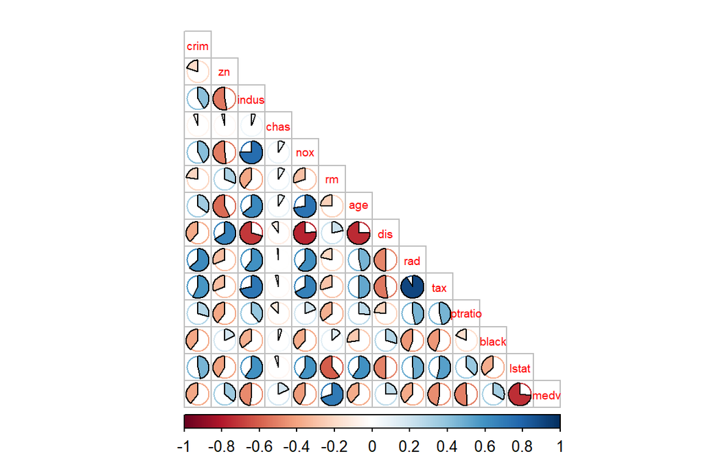

```r
#visualization of the correlation-matrix
corrplot(cor_matrix, method="pie", type="lower", cl.pos="b", tl.pos="d", tl.cex=0.6)
```

The positive correlations are displayed in blue, while the negative correlations are displayed in red. The respective color-shade, as well as, the size of the “pie-piece” are displayed proportionally to the correlation-coefficients.

This implies that of particular interest are the negative correlations between **dis** with the variables **indus**, **nox**, and **age**. On the other hand, outstanding appears to be the positive correlation between **tax** and **rad**. The least significant correlations appear to be with the variable **chas**.

```r
summary(Boston$crim)
```

```
##     Min.  1st Qu.   Median     Mean  3rd Qu.     Max.
##  0.00632  0.08204  0.25651  3.61352  3.67708 88.97620
```

```r
summary(Boston$zn)
```

```
##    Min. 1st Qu.  Median    Mean 3rd Qu.    Max.
##    0.00    0.00    0.00   11.36   12.50  100.00
```

```r
summary(Boston$indus)
```

```
##    Min. 1st Qu.  Median    Mean 3rd Qu.    Max.
##    0.46    5.19    9.69   11.14   18.10   27.74
```

```r
summary(Boston$chas)
```

```
##    Min. 1st Qu.  Median    Mean 3rd Qu.    Max.
## 0.00000 0.00000 0.00000 0.06917 0.00000 1.00000
```

```r
summary(Boston$nox)
```

```
##    Min. 1st Qu.  Median    Mean 3rd Qu.    Max.
##  0.3850  0.4490  0.5380  0.5547  0.6240  0.8710
```

```r
summary(Boston$rm)
```

```
##    Min. 1st Qu.  Median    Mean 3rd Qu.    Max.
##   3.561   5.886   6.208   6.285   6.623   8.780
```

```r
summary(Boston$age)
```

```
##    Min. 1st Qu.  Median    Mean 3rd Qu.    Max.
##    2.90   45.02   77.50   68.57   94.08  100.00
```

```r
summary(Boston$dis)
```

```
##    Min. 1st Qu.  Median    Mean 3rd Qu.    Max.
##   1.130   2.100   3.207   3.795   5.188  12.127
```

```r
summary(Boston$rad)
```

```
##    Min. 1st Qu.  Median    Mean 3rd Qu.    Max.
##   1.000   4.000   5.000   9.549  24.000  24.000
```

```r
summary(Boston$tax)
```

```
##    Min. 1st Qu.  Median    Mean 3rd Qu.    Max.
##   187.0   279.0   330.0   408.2   666.0   711.0
```

```r
summary(Boston$ptratio)
```

```
##    Min. 1st Qu.  Median    Mean 3rd Qu.    Max.
##   12.60   17.40   19.05   18.46   20.20   22.00
```

```r
summary(Boston$black)
```

```
##    Min. 1st Qu.  Median    Mean 3rd Qu.    Max.
##    0.32  375.38  391.44  356.67  396.23  396.90
```

```r
summary(Boston$lstat)
```

```
##    Min. 1st Qu.  Median    Mean 3rd Qu.    Max.
##    1.73    6.95   11.36   12.65   16.95   37.97
```

```r
summary(Boston$medv)
```

```
##    Min. 1st Qu.  Median    Mean 3rd Qu.    Max.
##    5.00   17.02   21.20   22.53   25.00   50.00
```

## Preparing the dataset

#### Scaling the dataset “Boston”

To fit the LDA-model to the dataset two specific assumptions must be fulfilled:

1. On condition of the classes, the variables must be normally distributed.
2. The variance of each variable must be the same.

In order, to achieve these the dataset “Boston” will now be standardized:

```r
#center and standardize "Boston" & changing the object to a dataframe
boston_scaled <- as.data.frame(scale(Boston))

#summarizing boston scaled
summary(boston_scaled)
```

```
##       crim                 zn               indus
##  Min.   :-0.419367   Min.   :-0.48724   Min.   :-1.5563
##  1st Qu.:-0.410563   1st Qu.:-0.48724   1st Qu.:-0.8668
##  Median :-0.390280   Median :-0.48724   Median :-0.2109
##  Mean   : 0.000000   Mean   : 0.00000   Mean   : 0.0000
##  3rd Qu.: 0.007389   3rd Qu.: 0.04872   3rd Qu.: 1.0150
##  Max.   : 9.924110   Max.   : 3.80047   Max.   : 2.4202
##       chas              nox                rm               age
##  Min.   :-0.2723   Min.   :-1.4644   Min.   :-3.8764   Min.   :-2.3331
##  1st Qu.:-0.2723   1st Qu.:-0.9121   1st Qu.:-0.5681   1st Qu.:-0.8366
##  Median :-0.2723   Median :-0.1441   Median :-0.1084   Median : 0.3171
##  Mean   : 0.0000   Mean   : 0.0000   Mean   : 0.0000   Mean   : 0.0000
##  3rd Qu.:-0.2723   3rd Qu.: 0.5981   3rd Qu.: 0.4823   3rd Qu.: 0.9059
##  Max.   : 3.6648   Max.   : 2.7296   Max.   : 3.5515   Max.   : 1.1164
##       dis               rad               tax             ptratio
##  Min.   :-1.2658   Min.   :-0.9819   Min.   :-1.3127   Min.   :-2.7047
##  1st Qu.:-0.8049   1st Qu.:-0.6373   1st Qu.:-0.7668   1st Qu.:-0.4876
##  Median :-0.2790   Median :-0.5225   Median :-0.4642   Median : 0.2746
##  Mean   : 0.0000   Mean   : 0.0000   Mean   : 0.0000   Mean   : 0.0000
##  3rd Qu.: 0.6617   3rd Qu.: 1.6596   3rd Qu.: 1.5294   3rd Qu.: 0.8058
##  Max.   : 3.9566   Max.   : 1.6596   Max.   : 1.7964   Max.   : 1.6372
##      black             lstat              medv
##  Min.   :-3.9033   Min.   :-1.5296   Min.   :-1.9063
##  1st Qu.: 0.2049   1st Qu.:-0.7986   1st Qu.:-0.5989
##  Median : 0.3808   Median :-0.1811   Median :-0.1449
##  Mean   : 0.0000   Mean   : 0.0000   Mean   : 0.0000
##  3rd Qu.: 0.4332   3rd Qu.: 0.6024   3rd Qu.: 0.2683
##  Max.   : 0.4406   Max.   : 3.5453   Max.   : 2.9865
```

#### Creating Variable “crime”

In the following steps I intend to create a new categorical variable, named **crime**, and use it to replace the original variable **crim**. The quantiles are used as break points for this categorical variable. Finally, the new dataset will be divided to train- and test-sets, so that 80% of the data belongs to the train-set.

This new variable contains the categories *low*, *med_low*, *med_high*, and *high*.

**This step is necessary, because the target-variable in an LDA must be categorical!**

```r
#summary of scaled variable "crim"
summary(boston_scaled$crim)
```

```
##      Min.   1st Qu.    Median      Mean   3rd Qu.      Max.
## -0.419367 -0.410563 -0.390280  0.000000  0.007389  9.924110
```

```r
#creating and printing the quantile vector of "crim"
bins <- quantile(boston_scaled$crim)

#printing quantile vector
bins
```

```
##           0%          25%          50%          75%         100%
## -0.419366929 -0.410563278 -0.390280295  0.007389247  9.924109610
```

```r
#creating categorical variable "crime"
crime <- cut(boston_scaled$crim, breaks = bins, include.lowest = TRUE, labels = c("low", "med_low", "med_high", "high"))

#creating table "crime"
table(crime)
```

```
## crime
##      low  med_low med_high     high
##      127      126      126      127
```

```r
#removing original variable "crim" from the dataset
boston_scaled <- dplyr::select(boston_scaled, -crim)

#adding new variable to scaled dataset
boston_scaled <- data.frame(boston_scaled, crime)

#number of rows in the "Boston" dataset
n <- nrow(boston_scaled)

#choosing 80% of the rows
ind <- sample(n, size = n * 0.8)

#creating the train-set
train <- boston_scaled[ind,]

#creating test-set
test <- boston_scaled[-ind,]

#saving the correct classes from test-data
correct_classes <- test$crime

#removing the variable "crime" from the test-data
test <- dplyr::select(test, -crime)
```

## Classification-Instrument: The Linear discriminant Analysis (LDA)

LDA is used for three mainpurposes:

1. the finding of variables that separate the data,
2. predicting the classes of new data, and
3. reducing dimensions (though this is not undertaken here).

The LDA will in this part of the exercise be fitted on the train-set. The categorical variable **crime** will serve as the target-variable, while the remaining variables of the dataset are used as predictor-variables.

```r
#fitting the lda on the train-set
lda.fit <- lda(crime~., data = train)

#printing the lda.fit-object
lda.fit
```

```
## Call:
## lda(crime ~ ., data = train)
##
## Prior probabilities of groups:
##       low   med_low  med_high      high
## 0.2599010 0.2450495 0.2400990 0.2549505
##
## Group means:
##                   zn      indus         chas        nox         rm
## low       0.96772398 -0.8789104 -0.084848104 -0.8703004  0.4665060
## med_low  -0.04287714 -0.3508390  0.006051757 -0.6351971 -0.1030319
## med_high -0.37142772  0.1567838  0.052380230  0.4377687  0.1221129
## high     -0.48724019  1.0170891 -0.004759149  1.0455794 -0.3465454
##                 age        dis        rad        tax    ptratio
## low      -0.8943488  0.8742148 -0.7007702 -0.7351158 -0.4528038
## med_low  -0.4474822  0.4391353 -0.5538062 -0.4965773 -0.1231646
## med_high  0.3722604 -0.3834720 -0.4052697 -0.3211385 -0.3813660
## high      0.8077325 -0.8563359  1.6384176  1.5142626  0.7811136
##                black       lstat        medv
## low       0.38073040 -0.78535962  0.55986084
## med_low   0.30939606 -0.19912336  0.04794238
## med_high  0.06934582 -0.09591276  0.22028201
## high     -0.91785012  0.93386416 -0.72128978
##
## Coefficients of linear discriminants:
##                 LD1          LD2         LD3
## zn       0.09040187  0.528910794 -1.10024427
## indus   -0.05395176 -0.177241690  0.21382120
## chas    -0.08163799  0.095869213  0.21888133
## nox      0.40677110 -0.999454225 -1.18352501
## rm      -0.07418392 -0.041724522 -0.09172811
## age      0.19149241 -0.309429274 -0.10345724
## dis     -0.14308836 -0.162804005  0.26890038
## rad      3.16167987  0.844661506 -0.28462287
## tax      0.02574226  0.115672111  0.63786854
## ptratio  0.12865749  0.009842550 -0.36855622
## black   -0.12506882  0.018202984  0.07688878
## lstat    0.27061535 -0.007199735  0.53902333
## medv     0.18892557 -0.395580063 -0.10429522
##
## Proportion of trace:
##    LD1    LD2    LD3
## 0.9504 0.0356 0.0140
```

The table above displays the LDA-function outcomes. As can be seen there, the LDA results in four classes (*low*, *med_low*, *med_high*, and *high*). These classes correspond to the four categories, which have been established with the variable “crime”. The remaining 13 variables are used as the predictor-variables. As the target-variable “crime” resulted in the four above mentioned classes, the produced coefficients of the LDA resulted in a number of three classes (4 classes - 1 = 3; LD1, LD2, and LD3) for each predictor-variable. As the *proportion of trace*, which signifies the *between-group-variance*, finally, demonstrates that LD1 explains ca. 95% - 96% of the between-group-variance.

*Something that I find very interesting - and I am not sure, if it points to me having made a mistake - is that everytime I knit this document anew, the values displayed in the “proportion of trace” appears to be changing a little. I am sure, I have not changed any potentially significant codes, though.*

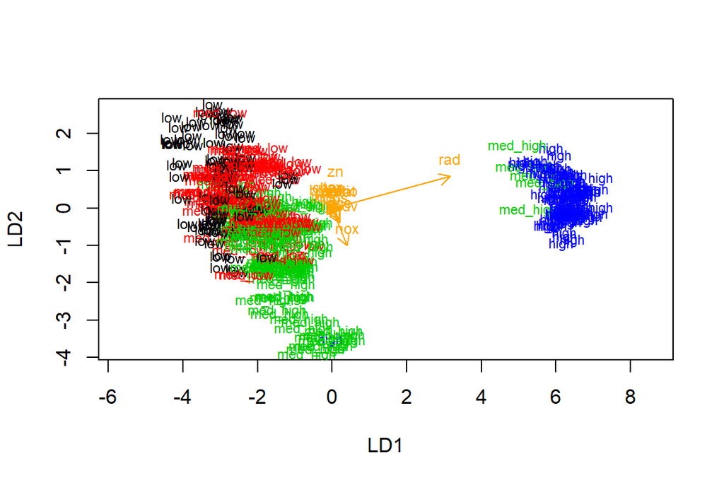

```r
#the function for the lda-biplot arrows
lda.arrows <- function(x, myscale = 1, arrow_heads = 0.1, color = "orange", tex = 0.75, choices = c(1,2)){
  heads <- coef(x)
  arrows(x0 = 0, y0 = 0,
         x1 = myscale * heads[,choices[1]],
         y1 = myscale * heads[,choices[2]], col = color, length = arrow_heads)
  text(myscale * heads[,choices], labels = row.names(heads),
       cex = tex, col = color, pos = 3)
}

#targeting classes as numeric
classes <- as.numeric(train$crime)

#plotting the lda results
plot(lda.fit, dimen = 2, col = classes, pch = classes)
lda.arrows(lda.fit, myscale = 1)
```

The LDA-biplot displays the four classes in the following colours:

- black = low
- red = med_low
- green = med_high
- blue = high.

An obviously interesting aspect is that the class “high” is strongly separated from the others (with a few exceptions of “med_high”).

The predictor variables are displayed as the orange arrows and they are based on the coefficients displayed in the table shown above the scatterplot. As the length and directions of these arrows displays, how each variable impacts on the LDA-model. Which makes the predictor-variable **rad**, as the one that sticks out from the others (both in direction and length of the arrow) particularly interesting. It is srongly directed towards the *cloud* of “high”.

#### LDA-predictions

LDA can serve as a means of classifying new observations. Based on the priorly used LDA-model, the probabilities for the new observations - those 20% of rows earlier sorted to the test-set - belonging to which class can be calculated.

Each of these observations is categorized by belonging to the class in accordance with the highest probability.

```r
#predicting classes with test-data
lda.pred <- predict(lda.fit, newdata = test)

#cross-tabulating the results
table(correct = correct_classes, predicted = lda.pred$class)
```

```
##           predicted
## correct    low med_low med_high high
##   low       12       9        1    0
##   med_low    1      15       11    0
##   med_high   0      10       18    1
##   high       0       0        0   24
```

## Clustering-Instruments: Distance Measures and K-Means

#### Re-Loading “Boston”

```r
#load the data
data("Boston")
```

```r
#center and standardize "Boston" & changing the object to a dataframe
boston_scaled_2 <- as.data.frame(scale(Boston))
```

#### Calculating distances

Distance measuring affects the results of cluster-analyses and is therefore particularly relevant for the the continuation of the analysis-process. Various approaches for measuring the distances are in use (e.g. euklidean distance, Manhattan or Taxicab distance, Jaccard-index, or the Hamming distance). Depending on the issues and dataset one can be more appropriate or promising for the analysis than another. As it was undertaken in the Datacamp-exercise, I will use the euclidean distance matrix (as it is generally the most common one) and the manhatten distance.

```r
#eucledian distance matrix
dist_eu <- dist(Boston)

#summarizing the euclidean distances
summary(dist_eu)
```

```
##    Min. 1st Qu.  Median    Mean 3rd Qu.    Max.
##   1.119  85.624 170.539 226.315 371.950 626.047
```

```r
#manhattan distance matrix
dist_man <- dist(Boston, method = "manhattan")

#summarizing manhattan-distances
summary(dist_man)
```

```
##     Min.  1st Qu.   Median     Mean  3rd Qu.     Max.
##    2.016  149.145  279.505  342.899  509.707 1198.265
```

These attempts show that the distances between the supposed clusters vary strongly according to the distance measure used.

#### Applying k-means

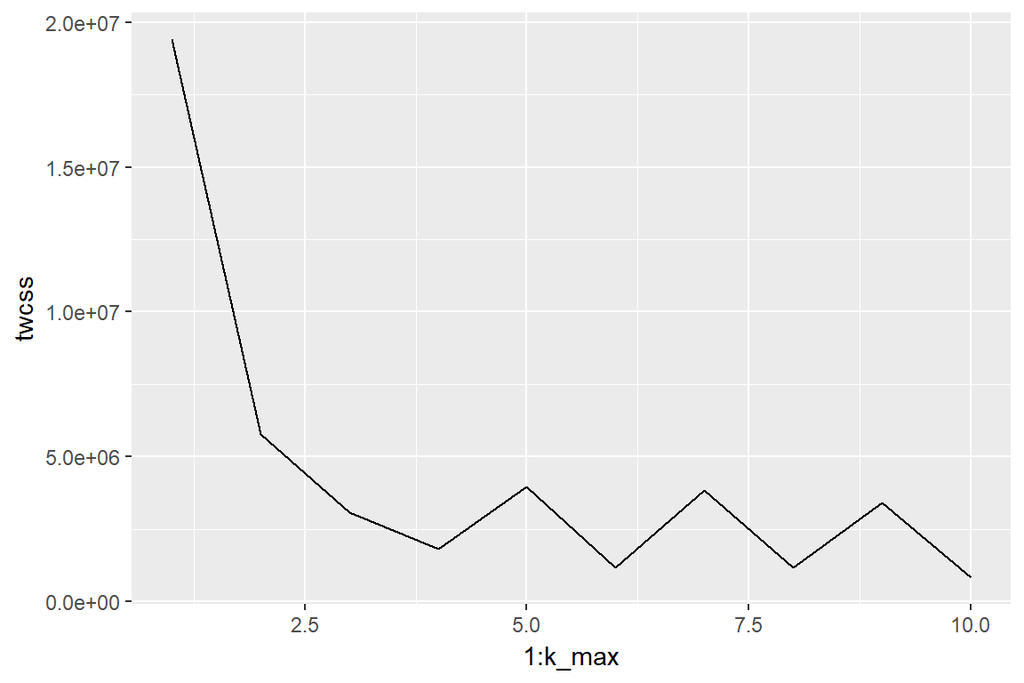

```r
set.seed(123)

#determining the number of clusters
k_max <- 10

#calculating the total within the sum of squares
twcss <- sapply(1:k_max, function(k){kmeans(Boston, k)$tot.withinss})

#visualizing results
qplot(x = 1:k_max, y = twcss, geom = 'line')
```

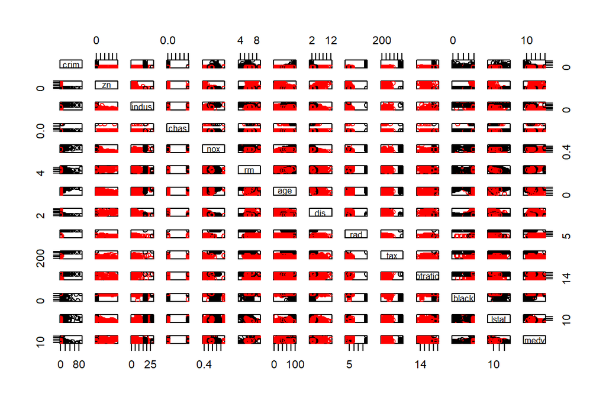

```r
#k-means clustering
km <- kmeans(Boston, centers = 2)

#plotting "Boston" with clusters
pairs (Boston, col = km$cluster)
```

The two clusters that resulted from the analysis are represented in the plot by the colors red and black. Supposedly, each datapoint (observation) of the dataset “Boston” has now been sorted into one of the two clusters. This sorting has been undertaken by reducing the randomly chosen initial cluster-amount of 10 down to 2 (or honestly, taken from the datacamp-exercise). Each observation should be sorted to the cluster, whose centroid is closest to it.

# **Dimensionality and Reduction Techniques**

For this exercise I use the newly created dataset *human*, which is based on the two datasets *hd* and *gii* from the *Human Development Index*. The original datasets consisted of 195 observations each, the hd-dataset originally included 7 observations, while the gii-dataset included 10 variables.

Four variables of the dataset were reduced to the number of two by combining the separate variables Edu2.F and Edu2.M to Edu2.FM and the separate variables to Lab.FM.

In order to create the dataset *human* the two sets have been joined by the variable *country*. The final seven observations have been removed, as they referred to the regions World, Sub-Saharan Africa, South Asia, Latin America and the Caribbean, Europe and Central Asia, East Asia and the Pacific, and Arab States, and as such not to specific countries.

As can be seen below the dataset *human* now consists of the following variables:

- **Life_Exp** refers to average life-expectency in the number of years from the date of birth
- **Exp_y_Edu** refers to the expected number of educational years
- **GNIpCap** refers to the Gross national income (GNI) per capita
- **MatMorRatio** refers to the Maternal mortality ratio
- **Adol_Birth_Rate** refers to the Adolescent birth rate
- **ParlRepPercent** refers to the women’s share of seats in parliament
- **Edu2.FM** refers to the population with at least some secondary education for both males and females of the age of at least 25)
- **Lab.FM** refers to the Labour force participation rate (for both males and females of the age of 15 or older)

Accessing libraries and loading the dataset “human”:

```r
#activating libraries:
library(tidyr)
library(corrplot)
library(ggplot2)
library(dplyr)
library(GGally)
#loading human:
human <- read.csv("C:\\Users\\Ani\\Documents\\GitHub\\IODS-project\\data\\human.csv", header=TRUE, row.names = 1)
```

Here we take a quick look at the structure and dimensions of the dataset:

```r
str(human)
```

```
## 'data.frame':    155 obs. of  8 variables:
##  $ Life_Exp       : num  81.6 82.4 83 80.2 81.6 80.9 80.9 79.1 82 81.8 ...
##  $ Exp_y_Edu      : num  17.5 20.2 15.8 18.7 17.9 16.5 18.6 16.5 15.9 19.2 ...
##  $ GNIpCap        : Factor w/ 155 levels "1,123","1,228",..: 132 109 124 112 113 111 103 123 108 93 ...
##  $ MatMorRatio    : int  4 6 6 5 6 7 9 28 11 8 ...
##  $ Adol_Birth_Rate: num  7.8 12.1 1.9 5.1 6.2 3.8 8.2 31 14.5 25.3 ...
##  $ ParlRepPercent : num  39.6 30.5 28.5 38 36.9 36.9 19.9 19.4 28.2 31.4 ...
##  $ Edu2.FM        : num  1.007 0.997 0.983 0.989 0.969 ...
##  $ Lab.FM         : num  0.891 0.819 0.825 0.884 0.829 ...
```

```r
dim(human)
```

```
## [1] 155   8
```

```r
rownames(human)
```

```
##   [1] "Norway"
##   [2] "Australia"
##   [3] "Switzerland"
##   [4] "Denmark"
##   [5] "Netherlands"
##   [6] "Germany"
##   [7] "Ireland"
##   [8] "United States"
##   [9] "Canada"
##  [10] "New Zealand"
##  [11] "Singapore"
##  [12] "Sweden"
##  [13] "United Kingdom"
##  [14] "Iceland"
##  [15] "Korea (Republic of)"
```

[output cut: 140 more lines]